# votes_rating

Jingsong Zhou

2023-12-06

##Dataset Columns: 1.product_parent: Random identifier that can be used to aggregate reviews for the same product. 2.star_rating: The 1-5 star rating of the review. 3.helpful_votes: Number of helpful votes. 4.total_votes: Number of total votes the review received. 5.verified_purchase The review is on a verified purchase.

```r
library(data.table)
library(dplyr)
```

```r
library(ggplot2)
```

```r
select_columns = c("product_parent", "star_rating", "helpful_votes", "total_votes", "verified_purchase")
```

```r
sports <- fread(file = "amazon_reviews_us_Sports_v1_00.tsv", quote = "", header = T, select = select_columns)
```

## 1.star ratings and verified/unverified purchases

The primary goal of this analysis was to ascertain whether there is a statistically significant difference in the star ratings given by customers who made verified purchases (denoted as “Y”) compared to those who did not (denoted as “N”) for each product in the dataset.

```r
library(dplyr)

# Specify the number of top products to select based on review counts
top_n_products = 20

# Select top products based on the total number of reviews
top_products <- sports %>%
  count(product_parent) %>%
  top_n(top_n_products, n) %>%
  select(product_parent)

# Function to perform t-test on each product
perform_t_test <- function(data) {
  verified_reviews <- filter(data, verified_purchase == "Y")$star_rating
  unverified_reviews <- filter(data, verified_purchase == "N")$star_rating

  return(t.test(verified_reviews, unverified_reviews, var.equal = FALSE)$p.value)
}

# Apply the function to each of the top products
test_results <- sports %>%
  filter(product_parent %in% top_products$product_parent) %>%
  group_by(product_parent) %>%
  do(t_test_result = perform_t_test(.))

# Adjust p-values for multiple testing, e.g., using Bonferroni correction
test_results <- test_results %>%
  mutate(adj_p_value = p.adjust(t_test_result, method = "bonferroni"))
```

First the dataset was filtered to include only those products that met the set threshold for total review counts. For each product that passed the filtering criteria, we conducted a two-sample t-test to compare the mean star ratings between the verified and unverified purchase reviews. Given that multiple hypothesis tests were conducted (one for each product), we adjusted the resulting p-values to account for multiple comparisons(Bonferroni correction).

##2. Impact of Review Ratings on Purchasing Decisions To investigate how reviews can help customers with their purchasing decisions and to identify what constitutes a “valuable” review, we need to delve into two aspects: how different levels of ratings impact customer decision-making and identify which reviews are most valuable based on their helpfulness votes.

```r
sports <- sports %>%
  filter(verified_purchase == "Y") %>%
  select(product_parent, star_rating, helpful_votes, total_votes)
```

1. Rating Distribution Analysis: Computation: Analyze the distribution of star ratings (1-5 stars) and observe which ratings are most common. Visualization: Use histograms or bar charts to show the frequency of each rating level.

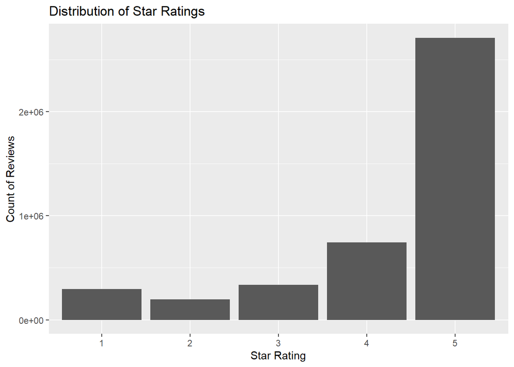

```r
ggplot(sports, aes(x = factor(star_rating))) +
  geom_bar() +
  xlab("Star Rating") +
  ylab("Count of Reviews") +
  ggtitle("Distribution of Star Ratings")
```

Interpretations: Customers might be more inclined to leave a review when they have a positive experience. There might be a tendency for satisfied customers to engage more in the reviewing process.

2. Correlation Between Ratings and Helpfulness: Box Plot: For each star rating, we can create a box plot of the helpful votes. This will show the distribution of helpful votes for each rating and is particularly useful for identifying outliers and the spread of the data.

Aggregate Data and Plot: Given the discrete nature of star ratings, calculating the average (or median) number of helpful votes for each rating and plotting these can provide a clear view of the relationship between star rating and helpful votes.

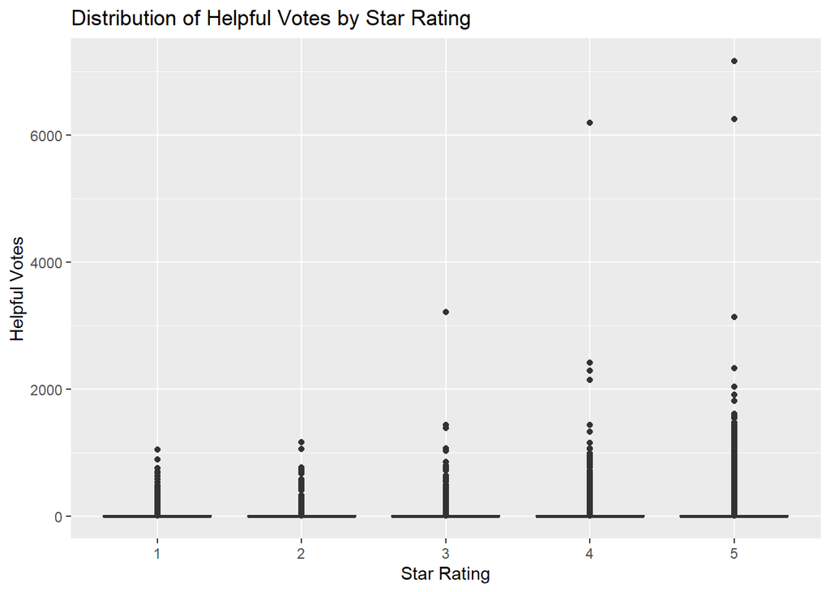

```r
# Box Plot
ggplot(sports, aes(x = factor(star_rating), y = helpful_votes)) +
  geom_boxplot() +
  xlab("Star Rating") +
  ylab("Helpful Votes") +
  ggtitle("Distribution of Helpful Votes by Star Rating")
```

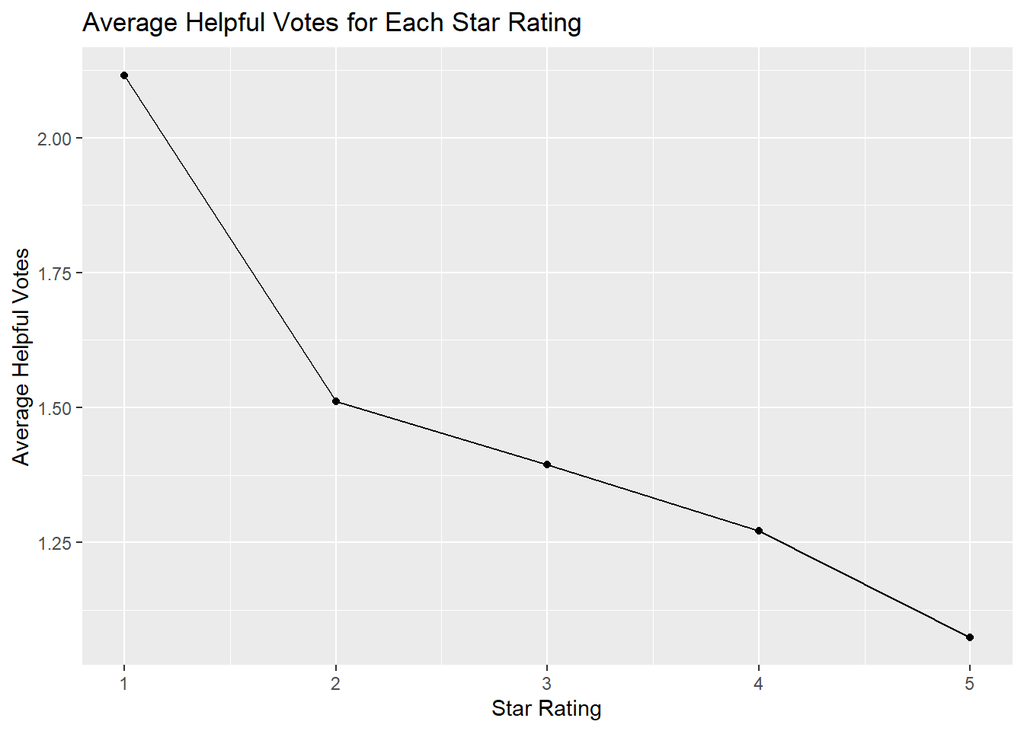

```r
# Aggregate Data and Plot
average_helpful_votes <- sports %>%
  group_by(star_rating) %>%
  summarise(avg_helpful_votes = mean(helpful_votes))

ggplot(average_helpful_votes, aes(x = star_rating, y = avg_helpful_votes)) +
  geom_line() +
  geom_point() +
  xlab("Star Rating") +
  ylab("Average Helpful Votes") +
  ggtitle("Average Helpful Votes for Each Star Rating")
```

Conclusion: Critical Reviews Valued More! Customers may find critical reviews (lower star ratings) more informative or valuable, especially when making purchase decisions. These reviews might offer more detailed insights into potential issues or drawbacks of a product.

## 3. Identifying Valuable Reviews Based on Votes

To determine the value of reviews based on votes:

1. Helpfulness Ratio Calculation: Computation: For each review, calculate the helpfulness ratio as helpful_votes / total_votes. A higher ratio indicates that the review was considered helpful by a greater proportion of those who voted.

```r
sports_helpful <- sports %>%
  mutate(helpfulness_ratio = ifelse(total_votes > 0, helpful_votes / total_votes, 0))
```

2. Threshold-Based Classification of Valuable Reviews: Setting Criteria: Define thresholds for classifying a review as ‘valuable’. For instance, a review could be deemed valuable if it has a helpfulness ratio above a certain percentage and a minimum number of total votes.

```r
helpfulness_threshold = 0.5
votes_threshold = 10
sports_helpful <- sports_helpful %>%
  mutate(is_valuable = helpfulness_ratio > helpfulness_threshold & total_votes > votes_threshold)
```

3. Analysis of Valuable Reviews Across Ratings: Computation: Compare the distribution of star ratings for reviews classified as valuable vs. those that aren’t. Visualization: Bar charts or box plots showing the distribution of star ratings for valuable and non-valuable reviews.

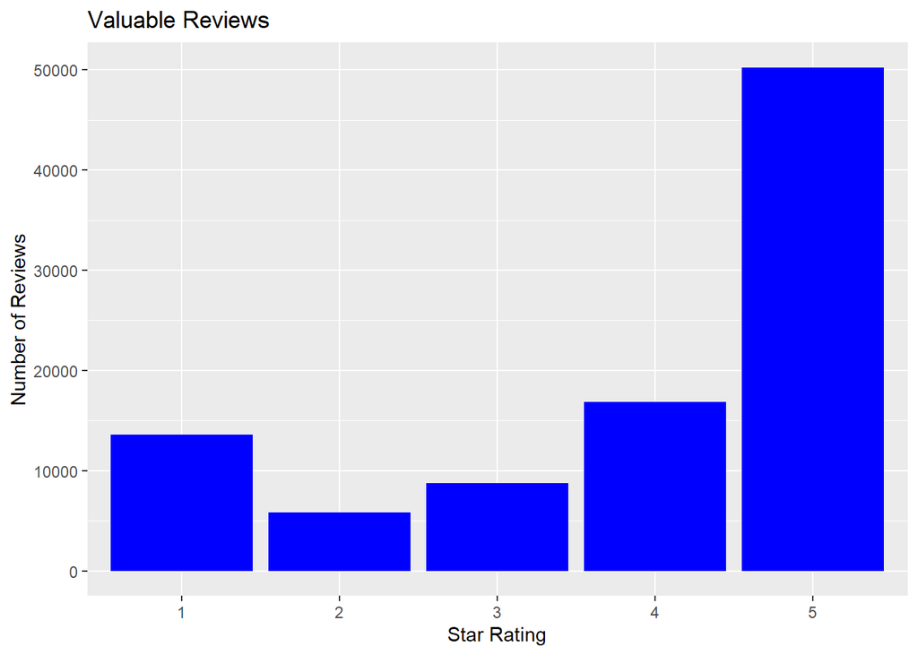

```r
# Comparing the distribution of star ratings
valuable_reviews <- sports_helpful %>% filter(is_valuable)
non_valuable_reviews <- sports_helpful %>% filter(!is_valuable)

# Visualization

par(mfrow = c(1, 2))

# Bar Chart for Valuable Reviews
ggplot(valuable_reviews, aes(x = as.factor(star_rating)))+
  geom_bar(fill = "blue") +
  ggtitle("Valuable Reviews") +
  xlab("Star Rating") +
  ylab("Number of Reviews")
```

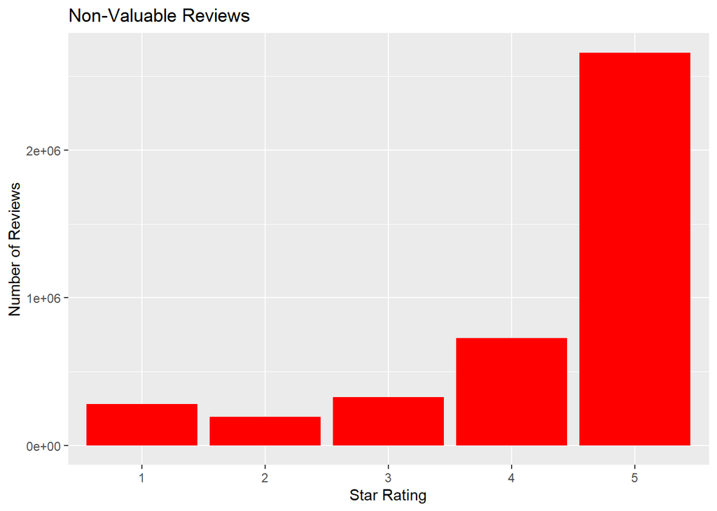

```r
# Bar Chart for Non-Valuable Reviews
ggplot(non_valuable_reviews, aes(x = as.factor(star_rating))) +
   geom_bar(fill = "red") +
  ggtitle("Non-Valuable Reviews") +
  xlab("Star Rating") +
  ylab("Number of Reviews")
```